# Figure 1 GH Comments

jcbioinformatics

2026-05-12

# Overview

Create figure showing number of comments for merged nf-core/modules PRs

Text file with counts should be generated with: `gh pr list --state merged --json number,title,comments --template '{{range .}}{{.number}}: {{.title}} ({{len .comments}} comments){{"\n"}}{{end}}' --limit 12000 > prs_merged_comments.txt` - Move into cloned repository prior to running that command - `gh` can be installed with conda (version 2.92.0 used).

## Parameters

Describe each parameter

- Paths
  - `input_path`: File containing PR information as generated with `gh pr list --state merged --json number,title,comments --template '{{range .}}{{.number}}: {{.title}} ({{len .comments}} comments){{"\n"}}{{end}}'`
- Processing
  - `comments_counts`: Comma delimited list of comment counts for PRs of interest
  - `comments_labels`: Comma delimited list of identifiers to use for PRs of interest
  - `prs_omit`: Comma delimited list of PR ids to omit

## Other Notes

Comment count does NOT necessarily equal number given for Conversation on the web since the counts in this case do NOT include replies or code review comments

```r
# Follow semantic versioning as described at:
# https://semver.org/

rmd_version <- "v1.0.0"
```

# Parameters

```r
for (par in names(params)){
  print(
    paste(
      par,
      params[[par]],
      sep = ": "
    )
  )
}
```

```
## [1] "comments_counts: 21,5"
## [1] "comments_labels: First,Second"
## [1] "prs_omit: 8680,8801"
## [1] "input_path: ./prs_merged_comments.txt"
```

# Processing

```r
library(ggrepel)
library(tidyverse)
comments_counts <- strsplit(params$comments_counts, split = ",")[[1]]
comments_labels <- strsplit(params$comments_labels, split = ",")[[1]]
prs_omit <- strsplit(params$prs_omit, split = ",")[[1]]
input_path <- params$input_path
```

```r
pr_comments_df <- read.table(
  input_path,
  sep = "\t",
  quote = "",
  comment.char = "",
  col.names = c("Data")
)

pr_comments_df_formatted <- pr_comments_df %>%
  mutate(
    ID = gsub(":.*", "", Data),
    Comments = gsub(
      ".*\\(([0-9]+) comments\\)$", "\\1", Data
    ),
    Comments = as.numeric(Comments),
    X_plot = "Comments"
  ) %>%
  filter(
    !ID %in% prs_omit
  )

my_comments_df <- data.frame(
  Label = comments_labels,
  Comments = comments_counts,
  X_plot = "Comments"
) %>%
  mutate(
    Comments = as.numeric(Comments)
  )
```

```r
boxplot_comments <- pr_comments_df_formatted %>%
  ggplot(
    aes(x = X_plot, y=Comments)
  ) +
  geom_boxplot(
    fill="#24B064",
    color="black",
    alpha=0.8
  ) +
  theme_bw() +
  theme(
    axis.text = element_text(size = 18),
    axis.text.x = element_blank(),
    axis.title = element_text(size = 24)
  ) +
  geom_point(
    data = my_comments_df,
    color = "forestgreen",
    size = 4
  ) +
  geom_text_repel(
    data = my_comments_df,
    nudge_x = 0.03,
    aes(
      label = Label
    ),
    size = 6,
    color = "darkgreen"
  ) +
  xlab("") +
  ylab("Comments Count")
```

# Results

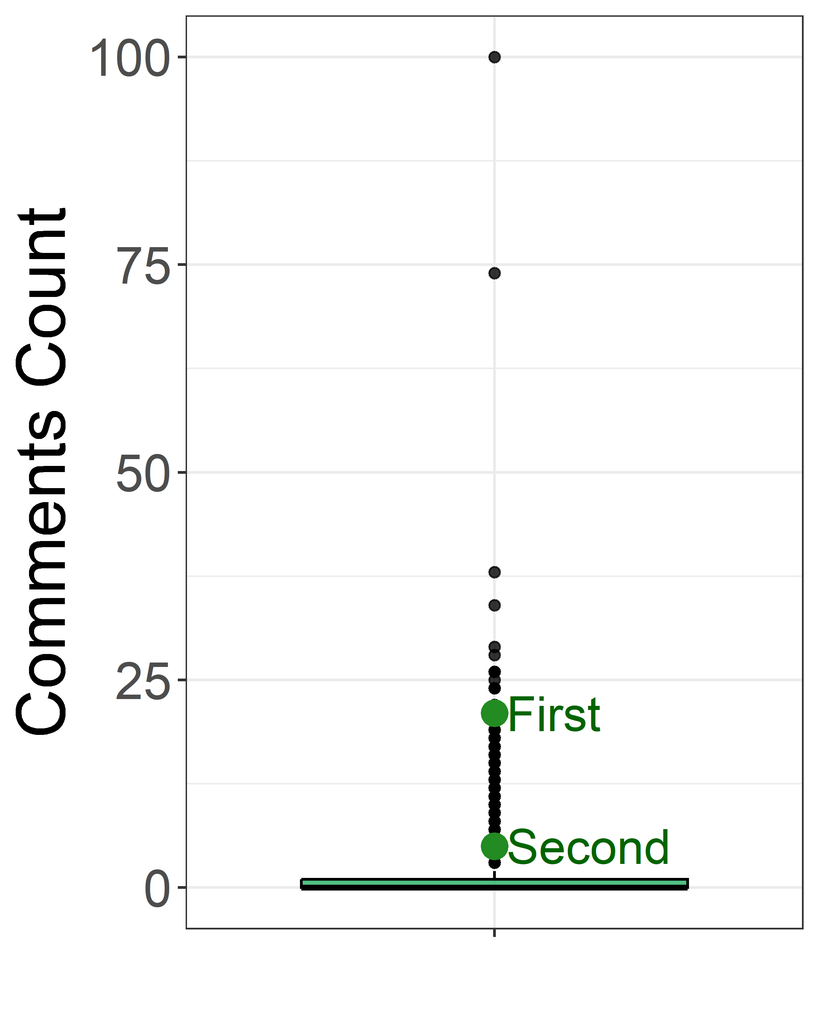

```r
boxplot_comments
```

# Versions

```r
print(
  paste(
    knitr::current_input(),
    "version:",
    rmd_version
  )
)
```

```
## [1] "LifeSciences_Figure1.Rmd version: v1.0.0"
```

```r
print(
  paste(
    "Executed:", Sys.time()
  )
)
```

```
## [1] "Executed: 2026-05-13 19:50:35.767857"
```